# Artificial Intelligence

## CA5-Phase2: Neural Network

## Teacher: Dr. Fadaei

### Student Name: Mohammadali Shakerdargah

### Student Number: 810098002

```python
import numpy as np
import pandas as pd
import tensorboard
import os

from tensorflow.keras import *
from tensorflow.keras.utils import *
import matplotlib.pyplot as plt
import matplotlib.image as mpimg
from PIL import Image
from sklearn.metrics import classification_report
```

```python
from google.colab import drive
drive.mount('/content/drive')
```

```python
!cp "/content/drive/MyDrive/Colab_Documents/AI/CA5/CA5_Phase2/UTKFace.tar.gz" .
```

```python
!tar -xvf UTKFace.tar.gz
```

[output not shown]

[output cut: 4946 more lines]

[output not shown]

```python
img_path = list()
races = list()
path = '/content/UTKFace'
for img in os.listdir(path):
  temp = img.split('.') # temp[0] = 26_0_0_20170117195612332
  if len(temp[0].split('_')) == 4:
    img_path.append(os.path.join(path, img))
    age, gender, race, date = temp[0].split('_')
    races.append(int(race))
  else:
    continue

class_labels = {0:"White", 1:"Black",2:"Asian", 3:"Indian", 4:"Others"}
races_list = [ list(to_categorical(i, len(class_labels))) for i in races]
races = [ str(to_categorical(i, len(class_labels))) for i in races]
```

```python
df = pd.DataFrame({'image':img_path, 'race':races})
df_to_print = pd.DataFrame({'image':img_path, 'race':races_list})
df
```

|  | image | race |
| --- | --- | --- |
| 0 | /content/UTKFace/35_1_4_20170117203326008.jpg.... | [0. 0. 0. 0. 1.] |
| 1 | /content/UTKFace/35_0_0_20170117152238029.jpg.... | [1. 0. 0. 0. 0.] |
| 2 | /content/UTKFace/39_1_4_20170105173036253.jpg.... | [0. 0. 0. 0. 1.] |
| 3 | /content/UTKFace/38_0_2_20170117120432535.jpg.... | [0. 0. 1. 0. 0.] |
| 4 | /content/UTKFace/1_0_2_20161219201319628.jpg.c... | [0. 0. 1. 0. 0.] |
| ... | ... | ... |
| 23700 | /content/UTKFace/37_0_3_20170119202228541.jpg.... | [0. 0. 0. 1. 0.] |
| 23701 | /content/UTKFace/25_0_1_20170113175802374.jpg.... | [0. 1. 0. 0. 0.] |
| 23702 | /content/UTKFace/18_1_0_20170109214601671.jpg.... | [1. 0. 0. 0. 0.] |
| 23703 | /content/UTKFace/32_1_1_20170113012741371.jpg.... | [0. 1. 0. 0. 0.] |
| 23704 | /content/UTKFace/28_0_0_20170119194754322.jpg.... | [1. 0. 0. 0. 0.] |

23705 rows × 2 columns

# Phase 1: Visualization and Preprocessing

## Phase 1 Part 1:

We have done ths part in the training and test devision before training

## Phase 1 Part 2:

In this part we are going to printnumber of data and number of classes. We use the dataframe that we made.

```python
print("Num of data: ", len(df))
print("Num of classes:", len(df_to_print['race'][0]))
```

```
Num of data:  23705
Num of classes: 5
```

## Phase 1 Part 3:

In this part we will show a barplot of Classes with their quantity

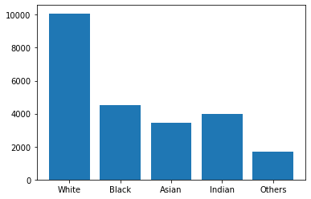

```python
class_1, class_2, class_3, class_4, class_5 = 0, 0, 0, 0, 0
for race in races_list:
  if(race[0] == 1):
    class_1 +=1
  if(race[1] == 1):
    class_2 +=1
  if(race[2] == 1):
    class_3 +=1
  if(race[3] == 1):
    class_4 +=1
  if(race[4] == 1):
    class_5 +=1

height = [class_1, class_2, class_3, class_4, class_5]
bars = ("White", "Black", "Asian", "Indian", "Others")
y_pos = np.arange(len(bars))
plt.bar(y_pos, height)
plt.xticks(y_pos, bars)
plt.show()
```

## Phase 1 Part 4:

In this part we are going to show only one picture of any class

```python
def print_image(path):
  plt.figure()
  img = Image.open(path).convert('LA')
  img.thumbnail((100, 100))
  plt.imshow(img)
```

```python
df['race'][0]
```

```
'[0. 0. 0. 0. 1.]'
```

```python
White =  "[1. 0. 0. 0. 0.]"
Black =  "[0. 1. 0. 0. 0.]"
Asian =  "[0. 0. 1. 0. 0.]"
Indian = "[0. 0. 0. 1. 0.]"
Others = "[0. 0. 0. 0. 1.]"
```

```
Information:                                                 image              race
1  /content/UTKFace/35_0_0_20170117152238029.jpg....  [1. 0. 0. 0. 0.]

White
```

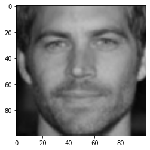

```python
print("Information: ",df.loc[df['race'] == White].head(1))
print("\nWhite")
print_image(df['image'][1])
```

```
Information:                                                 image              race
6  /content/UTKFace/28_0_1_20170117015425896.jpg....  [0. 1. 0. 0. 0.]

Black
```

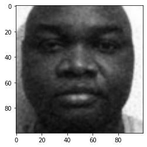

```python
print("Information: ",df.loc[df['race'] == Black].head(1))
print("\nBlack")
print_image(df['image'][6])
```

```
Information:                                                 image              race
3  /content/UTKFace/38_0_2_20170117120432535.jpg....  [0. 0. 1. 0. 0.]

Asian
```

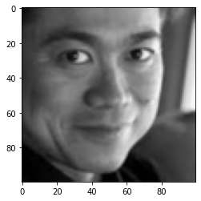

```python
print("Information: ",df.loc[df['race'] == Asian].head(1))
print("\nAsian")
print_image(df['image'][3])
```

```
Information:                                                  image              race
11  /content/UTKFace/70_0_3_20170119184325439.jpg....  [0. 0. 0. 1. 0.]

Indian
```

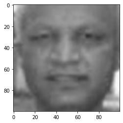

```python
print("Information: ",df.loc[df['race'] == Indian].head(1))
print("\nIndian")
print_image(df['image'][11])
```

```
Information:                                                 image              race
0  /content/UTKFace/35_1_4_20170117203326008.jpg....  [0. 0. 0. 0. 1.]

Others
```

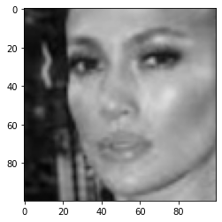

```python
print("Information: ",df.loc[df['race'] == Others].head(1))
print("\nOthers")
print_image(df['image'][0])
```

## Phase 1 Part 5:

We will devide our data to

- 80% Training set
- 20% Test set

```python
dataGenerator = preprocessing.image.ImageDataGenerator(rescale= 1/255.0, validation_split=0.2)
```

## Phase 1 Part 6:

As mentioned in previous projects, there are 2 way to approach.

- Label encoding has the advantage that it is straightforward but it has the disadvantage that the numeric values can be “misinterpreted” by the algorithms. For example, the value of 0 is obviously less than the value of 4 but does that really correspond to the data set in real life? Does a wagon have “4X” more weight in our calculation than the convertible? In this example, I don’t think so.
- A common alternative approach is called one hot encoding. Despite the different names, the basic strategy is to convert each category value into a new column and assigns a 1 or 0 (True/False) value to the column. ---> One-Hot has the benefit of not weighting a value improperly but does have the downside of adding more columns to the data set.

```python
print(df_to_print['race'])
```

```
0        [0.0, 0.0, 0.0, 0.0, 1.0]
1        [1.0, 0.0, 0.0, 0.0, 0.0]
2        [0.0, 0.0, 0.0, 0.0, 1.0]
3        [0.0, 0.0, 1.0, 0.0, 0.0]
4        [0.0, 0.0, 1.0, 0.0, 0.0]
                   ...
23700    [0.0, 0.0, 0.0, 1.0, 0.0]
23701    [0.0, 1.0, 0.0, 0.0, 0.0]
23702    [1.0, 0.0, 0.0, 0.0, 0.0]
23703    [0.0, 1.0, 0.0, 0.0, 0.0]
23704    [1.0, 0.0, 0.0, 0.0, 0.0]
Name: race, Length: 23705, dtype: object
```

```python
races_tuple = list()
for i in range(len(races_list)):
  races_tuple.append(tuple(races_list[i]))
```

```python
df_array_tuple = pd.DataFrame({'image':img_path, 'race': races_tuple})
df_array_tuple
```

|  | image | race |
| --- | --- | --- |
| 0 | /content/UTKFace/35_1_4_20170117203326008.jpg.... | (0.0, 0.0, 0.0, 0.0, 1.0) |
| 1 | /content/UTKFace/35_0_0_20170117152238029.jpg.... | (1.0, 0.0, 0.0, 0.0, 0.0) |
| 2 | /content/UTKFace/39_1_4_20170105173036253.jpg.... | (0.0, 0.0, 0.0, 0.0, 1.0) |
| 3 | /content/UTKFace/38_0_2_20170117120432535.jpg.... | (0.0, 0.0, 1.0, 0.0, 0.0) |
| 4 | /content/UTKFace/1_0_2_20161219201319628.jpg.c... | (0.0, 0.0, 1.0, 0.0, 0.0) |
| ... | ... | ... |
| 23700 | /content/UTKFace/37_0_3_20170119202228541.jpg.... | (0.0, 0.0, 0.0, 1.0, 0.0) |
| 23701 | /content/UTKFace/25_0_1_20170113175802374.jpg.... | (0.0, 1.0, 0.0, 0.0, 0.0) |
| 23702 | /content/UTKFace/18_1_0_20170109214601671.jpg.... | (1.0, 0.0, 0.0, 0.0, 0.0) |
| 23703 | /content/UTKFace/32_1_1_20170113012741371.jpg.... | (0.0, 1.0, 0.0, 0.0, 0.0) |
| 23704 | /content/UTKFace/28_0_0_20170119194754322.jpg.... | (1.0, 0.0, 0.0, 0.0, 0.0) |

23705 rows × 2 columns

# Phase 2: Neural Network Design

## Answer to one question: Parameters

Total params: 10,832,133. It is obvious that in neural networks we have "Weights" and "Bias" and in each layer there is a matrix with n*m enteries (n is the size of input of layer and m is the size of output of layer) so we have n*m parameters for weiht of each layer and we have m for the bias

```python
TrainData = dataGenerator.flow_from_dataframe(
    dataframe = df,
    x_col = 'image',
    y_col = 'race',
    target_size = (100, 100),
    color_mode = 'grayscale',
    batch_size = 32,
    class_mode = 'categorical',
    subset = 'training',
    shuffle = False
)
```

```
Found 18964 validated image filenames belonging to 5 classes.
```

```python
TrainData.class_indices
```

```
{'[0. 0. 0. 0. 1.]': 0,
 '[0. 0. 0. 1. 0.]': 1,
 '[0. 0. 1. 0. 0.]': 2,
 '[0. 1. 0. 0. 0.]': 3,
 '[1. 0. 0. 0. 0.]': 4}
```

```python
TestData = dataGenerator.flow_from_dataframe(
    dataframe = df,
    x_col = 'image',
    y_col = 'race',
    target_size = (100, 100),
    color_mode = 'grayscale',
    batch_size = 32,
    class_mode = 'categorical',
    subset = 'validation',
    shuffle = False
)
```

```
Found 4741 validated image filenames belonging to 5 classes.
```

```python
def get_proper_class(TestData_classes, y_pred_test, TrainData_classes, y_pred_train):
  y_pred_train_show = []
  TrainData_classes_show = []
  y_pred_test_show = []
  TestData_classes_show = []

  for i in range(len(y_pred_train)):
    if(y_pred_train[i]== 4):
      y_pred_train_show.append(0)
    if(y_pred_train[i]== 3):
      y_pred_train_show.append(1)
    if(y_pred_train[i]== 2):
      y_pred_train_show.append(2)
    if(y_pred_train[i]== 1):
      y_pred_train_show.append(3)
    if(y_pred_train[i]== 0):
      y_pred_train_show.append(4)

    if(TrainData_classes[i]== 4):
      TrainData_classes_show.append(0)
    if(TrainData_classes[i]== 3):
      TrainData_classes_show.append(1)
    if(TrainData_classes[i]== 2):
      TrainData_classes_show.append(2)
    if(TrainData_classes[i]== 1):
      TrainData_classes_show.append(3)
    if(TrainData_classes[i]== 0):
      TrainData_classes_show.append(4)

  for i in range(len(y_pred_test)):
    if(y_pred_test[i]== 4):
      y_pred_test_show.append(0)
    if(y_pred_test[i]== 3):
      y_pred_test_show.append(1)
    if(y_pred_test[i]== 2):
      y_pred_test_show.append(2)
    if(y_pred_test[i]== 1):
      y_pred_test_show.append(3)
    if(y_pred_test[i]== 0):
      y_pred_test_show.append(4)

    if(TestData_classes[i]== 4):
      TestData_classes_show.append(0)
    if(TestData_classes[i]== 3):
      TestData_classes_show.append(1)
    if(TestData_classes[i]== 2):
      TestData_classes_show.append(2)
    if(TestData_classes[i]== 1):
      TestData_classes_show.append(3)
    if(TestData_classes[i]== 0):
      TestData_classes_show.append(4)
  return TestData_classes_show, y_pred_test_show, TrainData_classes_show, y_pred_train_show
```

```python
input = layers.Input(shape=(100, 100, 1)) #Gray scale
output = layers.Flatten()(input)
output = layers.Dense(1024, activation="relu")(output)
output = layers.Dense(512, activation="relu")(output)
output = layers.Dense(128, activation="relu")(output)
output = layers.Dense(5, activation="softmax")(output)
```

```python
model = models.Model(inputs = input, outputs = output)
model.compile(optimizer = optimizers.SGD(learning_rate=0.01), loss = "categorical_crossentropy", metrics=["accuracy"])
```

```python
model.summary()
```

```
Model: "model"
_________________________________________________________________
Layer (type)                 Output Shape              Param #
=================================================================
input_1 (InputLayer)         [(None, 100, 100, 1)]     0
_________________________________________________________________
flatten (Flatten)            (None, 10000)             0
_________________________________________________________________
dense (Dense)                (None, 1024)              10241024
_________________________________________________________________
dense_1 (Dense)              (None, 512)               524800
_________________________________________________________________
dense_2 (Dense)              (None, 128)               65664
_________________________________________________________________
dense_3 (Dense)              (None, 5)                 645
=================================================================
Total params: 10,832,133
Trainable params: 10,832,133
Non-trainable params: 0
_________________________________________________________________
```

```python
history = model.fit(TrainData, validation_data = TestData, epochs = 10)
```

```python
Y_pred_train = model.predict(TrainData)
y_pred_train = np.argmax(Y_pred_train, axis=1)

Y_pred_test = model.predict(TestData)
y_pred_test = np.argmax(Y_pred_test, axis=1)
```

```python
target_names = ["White", "Black", "Asian", "Indian", "Others"]
TestData_classes_show, y_pred_test_show, TrainData_classes_show, y_pred_train_show = get_proper_class(TestData.classes, y_pred_test, TrainData.classes, y_pred_train)

print('\n For Train:')
print(classification_report(TrainData_classes_show , (y_pred_train_show), target_names=target_names))
# print('\n For Test:')
print(classification_report(TestData_classes_show , y_pred_test_show, target_names=target_names))
```

```
 For Train:
              precision    recall  f1-score   support

       White       0.65      0.93      0.77      8038
       Black       0.85      0.75      0.80      3662
       Asian       0.85      0.56      0.67      2767
      Indian       0.74      0.53      0.62      3187
      Others       0.40      0.04      0.07      1310

    accuracy                           0.71     18964
   macro avg       0.70      0.56      0.58     18964
weighted avg       0.72      0.71      0.69     18964

              precision    recall  f1-score   support

       White       0.64      0.92      0.76      2040
       Black       0.83      0.73      0.78       864
       Asian       0.83      0.56      0.67       667
      Indian       0.69      0.50      0.58       788
      Others       0.37      0.03      0.06       382

    accuracy                           0.69      4741
   macro avg       0.67      0.55      0.57      4741
weighted avg       0.69      0.69      0.66      4741
```

# Phase 3: Classification:

## Part 1: Optimizers

### *PDF FILE next to this file* 4 parts

- In the PDF FIle I have explained What adam and momentum benefits are and explained about them.
- After running with momentum 0.5 and 0.9 we can see that
  - momentum 0.5: Accuracy F1 = 73%
  - momentum 0.9: Accuracy F1 = 68% -> This thells us that with momentum 0.5 we got a better result
- We can totally see that the answer to this question is "NO", because instead of taking leading to faster converging it may start to diverge from optimal solution
- In the PDF FIle I have explained What adam benefits is and explained about it. After running with adam we can see that
  - Adam: Accuracy F1 = 74% (for train) -> This thells us that with adam we get a good result and we will continue with this

## [Source -> towardsdatascience](https://towardsdatascience.com/stochastic-gradient-descent-with-momentum-a84097641a5d#:~:text=In%20this%20post%20I'll,thus%20leading%20to%20faster%20converging.)

### Momentum = 0.5

```python
model = models.Model(inputs = input, outputs = output)
model.compile(optimizer = optimizers.SGD(learning_rate=0.01, momentum=0.5), loss = "categorical_crossentropy", metrics=["accuracy"])
history = model.fit(TrainData, validation_data=TestData, epochs = 10)
```

```python
Y_pred_train = model.predict(TrainData)
y_pred_train = np.argmax(Y_pred_train, axis=1)

Y_pred_test = model.predict(TestData)
y_pred_test = np.argmax(Y_pred_test, axis=1)

target_names = ["White", "Black", "Asian", "Indian", "Others"]
TestData_classes_show, y_pred_test_show, TrainData_classes_show, y_pred_train_show = get_proper_class(TestData.classes, y_pred_test, TrainData.classes, y_pred_train)

print('\n For Train:')
print(classification_report(TrainData_classes_show , (y_pred_train_show), target_names=target_names))
print('\n For Test:')
print(classification_report(TestData_classes_show , y_pred_test_show, target_names=target_names))
```

```
 For Train:
              precision    recall  f1-score   support

       White       0.75      0.94      0.83      8038
       Black       0.93      0.81      0.87      3662
       Asian       0.87      0.79      0.83      2767
      Indian       0.76      0.67      0.71      3187
      Others       0.65      0.16      0.26      1310

    accuracy                           0.80     18964
   macro avg       0.79      0.68      0.70     18964
weighted avg       0.80      0.80      0.78     18964

              precision    recall  f1-score   support

       White       0.71      0.91      0.80      2040
       Black       0.86      0.74      0.80       864
       Asian       0.78      0.73      0.75       667
      Indian       0.68      0.60      0.63       788
      Others       0.44      0.09      0.15       382

    accuracy                           0.73      4741
   macro avg       0.69      0.61      0.63      4741
weighted avg       0.72      0.73      0.71      4741
```

### Momentum = 0.9

```python
model = models.Model(inputs = input, outputs = output)
model.compile(optimizer = optimizers.SGD(learning_rate=0.01, momentum=0.9), loss = "categorical_crossentropy", metrics=["accuracy"])
history = model.fit(TrainData, validation_data=TestData, epochs = 10)
```

```python
Y_pred_train = model.predict(TrainData)
y_pred_train = np.argmax(Y_pred_train, axis=1)

Y_pred_test = model.predict(TestData)
y_pred_test = np.argmax(Y_pred_test, axis=1)

target_names = ["White", "Black", "Asian", "Indian", "Others"]
TestData_classes_show, y_pred_test_show, TrainData_classes_show, y_pred_train_show = get_proper_class(TestData.classes, y_pred_test, TrainData.classes, y_pred_train)

print('\n For Train:')
print(classification_report(TrainData_classes_show , (y_pred_train_show), target_names=target_names))
# print('\n For Test:')
print(classification_report(TestData_classes_show , y_pred_test_show, target_names=target_names))
```

```
 For Train:
              precision    recall  f1-score   support

       White       0.69      0.91      0.79      8038
       Black       0.91      0.66      0.77      3662
       Asian       0.92      0.51      0.65      2767
      Indian       0.58      0.74      0.65      3187
      Others       0.33      0.07      0.11      1310

    accuracy                           0.71     18964
   macro avg       0.69      0.58      0.59     18964
weighted avg       0.73      0.71      0.69     18964

              precision    recall  f1-score   support

       White       0.67      0.90      0.77      2040
       Black       0.86      0.62      0.72       864
       Asian       0.88      0.46      0.61       667
      Indian       0.56      0.70      0.62       788
      Others       0.22      0.03      0.06       382

    accuracy                           0.68      4741
   macro avg       0.64      0.54      0.55      4741
weighted avg       0.68      0.68      0.65      4741
```

### Adam

```python
model = models.Model(inputs = input, outputs = output)
model.compile(optimizer='Adam', loss = "categorical_crossentropy", metrics=["accuracy"])
history = model.fit(TrainData, validation_data=TestData, epochs = 10)
```

```python
Y_pred_train = model.predict(TrainData)
y_pred_train = np.argmax(Y_pred_train, axis=1)

Y_pred_test = model.predict(TestData)
y_pred_test = np.argmax(Y_pred_test, axis=1)

target_names = ["White", "Black", "Asian", "Indian", "Others"]
TestData_classes_show, y_pred_test_show, TrainData_classes_show, y_pred_train_show = get_proper_class(TestData.classes, y_pred_test, TrainData.classes, y_pred_train)

print('\n For Train:')
print(classification_report(TrainData_classes_show , (y_pred_train_show), target_names=target_names))
# print('\n For Test:')
print(classification_report(TestData_classes_show , y_pred_test_show, target_names=target_names))
```

```
 For Train:
              precision    recall  f1-score   support

       White       0.75      0.87      0.81      8038
       Black       0.88      0.71      0.79      3662
       Asian       0.77      0.77      0.77      2767
      Indian       0.61      0.75      0.68      3187
      Others       0.29      0.00      0.00      1310

    accuracy                           0.74     18964
   macro avg       0.66      0.62      0.61     18964
weighted avg       0.72      0.74      0.72     18964

              precision    recall  f1-score   support

       White       0.73      0.85      0.78      2040
       Black       0.86      0.68      0.76       864
       Asian       0.72      0.73      0.73       667
      Indian       0.57      0.72      0.64       788
      Others       0.50      0.00      0.01       382

    accuracy                           0.71      4741
   macro avg       0.68      0.60      0.58      4741
weighted avg       0.71      0.71      0.68      4741
```

## Part 2: Epochs

- We will train with 20 epochs
- Question: Why do we need to perform our learning algorith in several epochs?
  - Because the most common method for training in deep learning is a form of gradient descent. Each epoch finds the approximate direction that each parameter needs to be adjusted but it's just approximate. If you adjust too much in one epoch you will overshoot the set of parameters you're actually trying to find.
- Question: Is it always better to have more epochs?
  - NO, the algorithm may overfit on training DATA and can't get generalized on test data. large epochs may lead to huge error on test data.
- Question: What should we do ?
  - A very special way to deal with this types of situations, is "VALIDATION AND STOP". in this way we would make a validation test on the epoch we are entering if the result was not satisfactory, we would cease the operation,
  - Another way to do it is to define a threshhold that we desire and when it made the difference between highest accuracy and present accuracy, it will cease the operation.

```python
model = models.Model(inputs = input, outputs = output)
model.compile(optimizer='Adam', loss = "categorical_crossentropy", metrics=["accuracy"])
history = model.fit(TrainData, validation_data=TestData, epochs = 20)
```

```python
Y_pred_train = model.predict(TrainData)
y_pred_train = np.argmax(Y_pred_train, axis=1)

Y_pred_test = model.predict(TestData)
y_pred_test = np.argmax(Y_pred_test, axis=1)

target_names = ["White", "Black", "Asian", "Indian", "Others"]
TestData_classes_show, y_pred_test_show, TrainData_classes_show, y_pred_train_show = get_proper_class(TestData.classes, y_pred_test, TrainData.classes, y_pred_train)

print('\n For Train:')
print(classification_report(TrainData_classes_show , (y_pred_train_show), target_names=target_names))
print('\n For Test:')
print(classification_report(TestData_classes_show , y_pred_test_show, target_names=target_names))
```

```
 For Train:
              precision    recall  f1-score   support

       White       0.77      0.86      0.81      8077
       Black       0.87      0.77      0.82      3589
       Asian       0.69      0.81      0.75      2753
      Indian       0.66      0.71      0.68      3192
      Others       0.49      0.04      0.07      1353

    accuracy                           0.75     18964
   macro avg       0.70      0.64      0.63     18964
weighted avg       0.74      0.75      0.73     18964


 For Test:
              precision    recall  f1-score   support

       White       0.74      0.82      0.78      2001
       Black       0.82      0.72      0.76       937
       Asian       0.65      0.80      0.71       681
      Indian       0.61      0.65      0.63       783
      Others       0.11      0.01      0.01       339

    accuracy                           0.71      4741
   macro avg       0.59      0.60      0.58      4741
weighted avg       0.68      0.71      0.69      4741
```

## Part 3: Loss function

[source -> towardsdatascience](https://towardsdatascience.com/why-using-mean-squared-error-mse-cost-function-for-binary-classification-is-a-bad-idea-933089e90df7)

```python
model = models.Model(inputs = input, outputs = output)
model.compile(optimizer='Adam', loss = "mean_squared_error", metrics=["accuracy"])
history = model.fit(TrainData, validation_data=TestData, epochs = 20)
```

```python
Y_pred_train = model.predict(TrainData)
y_pred_train = np.argmax(Y_pred_train, axis=1)

Y_pred_test = model.predict(TestData)
y_pred_test = np.argmax(Y_pred_test, axis=1)

target_names = ["White", "Black", "Asian", "Indian", "Others"]
TestData_classes_show, y_pred_test_show, TrainData_classes_show, y_pred_train_show = get_proper_class(TestData.classes, y_pred_test, TrainData.classes, y_pred_train)

print('\n For Train:')
print(classification_report(TrainData_classes_show , (y_pred_train_show), target_names=target_names))
print('\n For Test:')
print(classification_report(TestData_classes_show , y_pred_test_show, target_names=target_names))
```

```
 For Train:
              precision    recall  f1-score   support

       White       0.77      0.88      0.82      8077
       Black       0.83      0.85      0.84      3589
       Asian       0.65      0.87      0.74      2753
      Indian       0.83      0.49      0.61      3192
      Others       0.41      0.14      0.21      1353

    accuracy                           0.75     18964
   macro avg       0.70      0.65      0.64     18964
weighted avg       0.75      0.75      0.73     18964


 For Test:
              precision    recall  f1-score   support

       White       0.73      0.84      0.78      2001
       Black       0.77      0.78      0.78       937
       Asian       0.61      0.84      0.70       681
      Indian       0.76      0.43      0.55       783
      Others       0.27      0.08      0.12       339

    accuracy                           0.71      4741
   macro avg       0.63      0.59      0.59      4741
weighted avg       0.69      0.71      0.68      4741
```

## Part 4: regularization

- Regularizers allow you to apply penalties on layer parameters or layer activity during optimization. These penalties are summed into the loss function that the network optimizes.
- L2 regulization
  - L2 regularization adds an L2 penalty equal to the square of the magnitude of coefficients. L2 will not yield sparse models and all coefficients are shrunk by the same factor (none are eliminated). -> RESULT:

    ```
     for train accuracy:  75%    18964
     for test accuracy:   72%    4741
     -> Good but not way better
    ```

- Dropout is a regularization
  - method that approximates training a large number of neural networks with different architectures in parallel.During training, some number of layer outputs are randomly ignored or “dropped out.” This has the effect of making the layer look-like and be treated-like a layer with a different number of nodes and connectivity to the prior layer. In effect, each update to a layer during training is performed with a different “view” of the configured layer. -> RESULT:

    ```
     for train accuracy:  54%     18964
     for test accuracy:   54%      4741
     -> It was NOT wise to put Dropout in all the layers. It was better to only put them in some layers.
    ```

### regularizers.l2

```python
from tensorflow.keras import regularizers
# from tensorflow.keras import layers
import tensorflow as tf
input = layers.Input(shape=(100, 100, 1)) #Gray scale
output = layers.Flatten()(input)

output = layers.Dense(1024, activation="relu", kernel_regularizer=regularizers.l2(l2=1e-4))(output)
output = layers.Dense(512, activation="relu", kernel_regularizer=regularizers.l2(l2=1e-4))(output)
output = layers.Dense(128, activation="relu", kernel_regularizer=regularizers.l2(l2=1e-4))(output)

output = layers.Dense(5, activation="softmax")(output)

model = models.Model(inputs = input, outputs = output)
model.compile(optimizer='Adam', loss = "categorical_crossentropy", metrics=["accuracy"])
history = model.fit(TrainData, validation_data=TestData, epochs = 20)
```

```python
Y_pred_train = model.predict(TrainData)
y_pred_train = np.argmax(Y_pred_train, axis=1)

Y_pred_test = model.predict(TestData)
y_pred_test = np.argmax(Y_pred_test, axis=1)

target_names = ["White", "Black", "Asian", "Indian", "Others"]
TestData_classes_show, y_pred_test_show, TrainData_classes_show, y_pred_train_show = get_proper_class(TestData.classes, y_pred_test, TrainData.classes, y_pred_train)

print('\n For Train:')
print(classification_report(TrainData_classes_show , (y_pred_train_show), target_names=target_names))
print('\n For Test:')
print(classification_report(TestData_classes_show , y_pred_test_show, target_names=target_names))
```

```
 For Train:
              precision    recall  f1-score   support

       White       0.75      0.87      0.81      8077
       Black       0.85      0.77      0.81      3589
       Asian       0.77      0.74      0.75      2753
      Indian       0.64      0.72      0.67      3192
      Others       0.52      0.03      0.06      1353

    accuracy                           0.75     18964
   macro avg       0.71      0.63      0.62     18964
weighted avg       0.74      0.75      0.72     18964


 For Test:
              precision    recall  f1-score   support

       White       0.73      0.85      0.79      2001
       Black       0.82      0.73      0.77       937
       Asian       0.73      0.72      0.73       681
      Indian       0.59      0.68      0.64       783
      Others       0.24      0.01      0.03       339

    accuracy                           0.72      4741
   macro avg       0.62      0.60      0.59      4741
weighted avg       0.69      0.72      0.70      4741
```

### Dropout all layers

```python
input = layers.Input(shape=(100, 100, 1)) #Gray scale
output = layers.Flatten()(input)

output = layers.Dense(1024, activation="relu")(output)
output = layers.Dropout(0.1)(output)
output = layers.Dense(512, activation="relu")(output)
output = layers.Dropout(0.1)(output)
output = layers.Dense(128, activation="relu")(output)
output = layers.Dropout(0.1)(output)

output = layers.Dense(5, activation="softmax")(output)

model = models.Model(inputs = input, outputs = output)
model.compile(optimizer='Adam', loss = "categorical_crossentropy", metrics=["accuracy"])
history = model.fit(TrainData, validation_data=TestData, epochs = 20)
```

```python
Y_pred_train = model.predict(TrainData)
y_pred_train = np.argmax(Y_pred_train, axis=1)

Y_pred_test = model.predict(TestData)
y_pred_test = np.argmax(Y_pred_test, axis=1)

target_names = ["White", "Black", "Asian", "Indian", "Others"]
TestData_classes_show, y_pred_test_show, TrainData_classes_show, y_pred_train_show = get_proper_class(TestData.classes, y_pred_test, TrainData.classes, y_pred_train)

print('\n For Train:')
print(classification_report(TrainData_classes_show , (y_pred_train_show), target_names=target_names))
print('\n For Test:')
print(classification_report(TestData_classes_show , y_pred_test_show, target_names=target_names))
```

```
 For Train:
              precision    recall  f1-score   support

       White       0.56      0.79      0.66      8077
       Black       0.50      0.90      0.64      3589
       Asian       0.89      0.19      0.31      2753
      Indian       0.33      0.07      0.11      3192
      Others       0.00      0.00      0.00      1353

    accuracy                           0.54     18964
   macro avg       0.46      0.39      0.34     18964
weighted avg       0.52      0.54      0.46     18964


 For Test:
              precision    recall  f1-score   support

       White       0.56      0.79      0.66      2001
       Black       0.50      0.88      0.64       937
       Asian       0.93      0.19      0.31       681
      Indian       0.24      0.04      0.07       783
      Others       0.00      0.00      0.00       339

    accuracy                           0.54      4741
   macro avg       0.45      0.38      0.33      4741
weighted avg       0.51      0.54      0.46      4741
```

## Best Neural Network: 10 TP and 10 FP

### True detection

```python
model = models.Model(inputs = input, outputs = output)
model.compile(optimizer='Adam', loss = "mean_squared_error", metrics=["accuracy"])
history = model.fit(TrainData, validation_data=TestData, epochs = 20)

Y_pred_train = model.predict(TrainData)
y_pred_train = np.argmax(Y_pred_train, axis=1)

Y_pred_test = model.predict(TestData)
y_pred_test = np.argmax(Y_pred_test, axis=1)

TestData.class_indices
```

```
class: White
class: Black
class: Black
class: Black
class: White
class: White
class: Black
class: Black
class: White
class: White
```

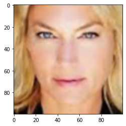

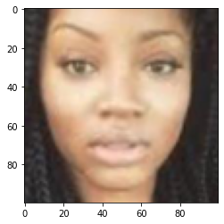

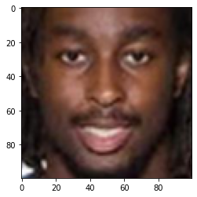

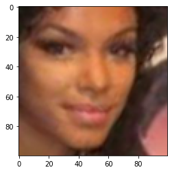

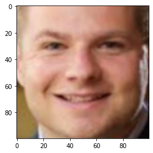

[figure not shown]

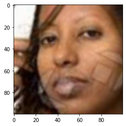

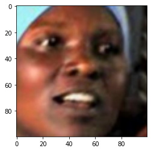

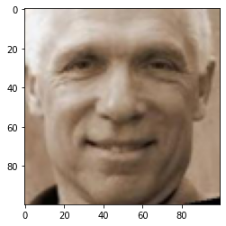

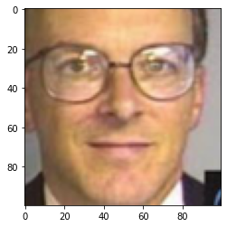

```python
cnt = 0
for i in range(len(TrainData.classes)):
  if(cnt == 10):
    break
  if(y_pred_train[i] == TrainData.classes[i]):
    if(y_pred_train[i] == 4):
      print("class: White")
    elif(y_pred_train[i] == 3):
      print("class: Black")
    plt.figure()
    img = Image.open(TrainData.filenames[i])
    img.thumbnail((100, 100))
    plt.imshow(img)
    cnt += 1
```

### False detection

```
True class:  2
Predicted class:  0
-------------------------------------------
True class:  0
Predicted class:  1
-------------------------------------------
True class:  2
Predicted class:  0
-------------------------------------------
True class:  3
Predicted class:  0
-------------------------------------------
True class:  3
Predicted class:  0
-------------------------------------------
True class:  2
Predicted class:  0
-------------------------------------------
True class:  4
Predicted class:  0
-------------------------------------------
True class:  4
Predicted class:  1
-------------------------------------------
True class:  4
Predicted class:  0
-------------------------------------------
True class:  2
Predicted class:  1
-------------------------------------------
```

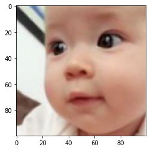

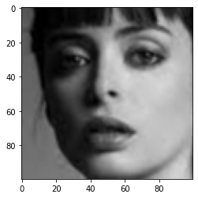

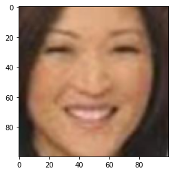

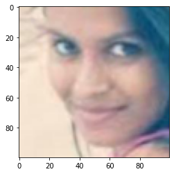

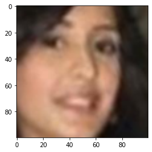

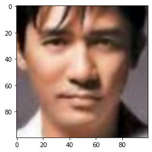

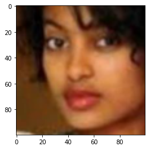

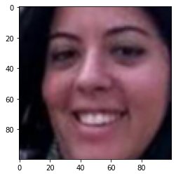

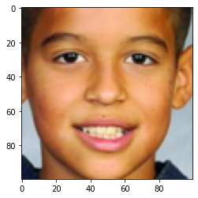

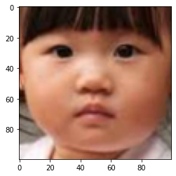

```python
cnt = 0
TestData_classes_show, y_pred_test_show, TrainData_classes_show, y_pred_train_show = get_proper_class(TestData.classes, y_pred_test, TrainData.classes, y_pred_train)
for i in range(len(TrainData_classes_show)):
  if(cnt == 10):
    break
  if(y_pred_train_show[i] != TrainData_classes_show[i]):
    print("True class: ", TrainData_classes_show[i])
    print("Predicted class: ", y_pred_train_show[i])
    print('-------------------------------------------')
    plt.figure()
    img = Image.open(TrainData.filenames[i])
    img.thumbnail((100, 100))
    plt.imshow(img)
    cnt += 1
```

# Phase 4: Data sketch with dimension reduction

```python
from tensorflow.keras import regularizers
# from tensorflow.keras import layers
import tensorflow as tf

input = layers.Input(shape=(100, 100, 1)) #Gray scale
output = layers.Flatten()(input)

#Encoder - Begin
output = layers.Dense(10000, activation="relu", kernel_regularizer=regularizers.l2(l2=1e-4))(output)
output = layers.Dense(1024, activation="relu", kernel_regularizer=regularizers.l2(l2=1e-4))(output)
output = layers.Dense(512, activation="relu", kernel_regularizer=regularizers.l2(l2=1e-4))(output)
output = layers.Dense(64, activation="relu", kernel_regularizer=regularizers.l2(l2=1e-4))(output)
output = layers.Dense(32, activation="relu", kernel_regularizer=regularizers.l2(l2=1e-4))(output)
output2 = layers.Dense(2, activation="relu", kernel_regularizer=regularizers.l2(l2=1e-4))(output)

#Encoder - End
output = layers.Dense(5, activation="softmax")(output2)

model = models.Model(inputs = input, outputs = output, name='encoder')
model.compile(optimizer='Adam', loss = "categorical_crossentropy", metrics=["accuracy"])
history = model.fit(TrainData, validation_data=TestData, epochs = 20)
```

```python
from tensorflow.keras import regularizers
# from tensorflow.keras import layers
import tensorflow as tf

input = layers.Input(shape=(100, 100, 1)) #Gray scale
output = layers.Flatten()(input)

#Encoder - Begin
output = layers.Dense(10000, activation="relu", kernel_regularizer=regularizers.l2(l2=1e-4))(output)
output = layers.Dense(1024, activation="relu", kernel_regularizer=regularizers.l2(l2=1e-4))(output)
output = layers.Dense(512, activation="relu", kernel_regularizer=regularizers.l2(l2=1e-4))(output)
output = layers.Dense(64, activation="relu", kernel_regularizer=regularizers.l2(l2=1e-4))(output)
output = layers.Dense(32, activation="relu", kernel_regularizer=regularizers.l2(l2=1e-4))(output)
output2 = layers.Dense(2, activation="relu", kernel_regularizer=regularizers.l2(l2=1e-4))(output)

#Encoder - End
output = layers.Dense(5, activation="softmax")(output2)

model = models.Model(inputs = input, outputs = output2, name='encoder')
model.compile(optimizer='Adam', loss = "categorical_crossentropy", metrics=["accuracy"])
history = model.fit(TrainData, validation_data=TestData, epochs = 20)
```

[output not shown]

```python
original_dim = 100*100
intermediate_dim = 1000
latent_dim = 2

inputs = Input(shape=(original_dim,))
h = layers.Dense(intermediate_dim, activation='relu')(inputs)
z_mean = layers.Dense(latent_dim)(h)
z_log_sigma = layers.Dense(latent_dim)(h)
```

```python
from keras import backend as K

def sampling(args):
    z_mean, z_log_sigma = args
    epsilon = K.random_normal(shape=(K.shape(z_mean)[0], latent_dim),
                              mean=0., stddev=0.1)
    return z_mean + K.exp(z_log_sigma) * epsilon

z = layers.Lambda(sampling)([z_mean, z_log_sigma])
```

```python
# Create encoder
encoder = Model(inputs, [z_mean, z_log_sigma], name='encoder')

# Create decoder
latent_inputs = Input(shape=(latent_dim,), name='z_sampling')
x = layers.Dense(intermediate_dim, activation='relu')(latent_inputs)
outputs = layers.Dense(original_dim, activation='sigmoid')(x)
decoder = Model(latent_inputs, outputs, name='decoder')

# instantiate VAE model
outputs = decoder(encoder(inputs)[1])
vae = Model(inputs, outputs, name='vae_mlp')
```

```python
reconstruction_loss = losses.binary_crossentropy(inputs, outputs)
reconstruction_loss *= original_dim
kl_loss = 1 + z_log_sigma - K.square(z_mean) - K.exp(z_log_sigma)
kl_loss = K.sum(kl_loss, axis=-1)
kl_loss *= -0.5
vae_loss = K.mean(reconstruction_loss + kl_loss)
vae.add_loss(vae_loss)
vae.compile(optimizer='adam')
```

```python
history = vae.fit(TrainData, validation_data=TestData, epochs = 20)
```

[output not shown]

[output not shown]